# Il DRS e i sorpassi in Formula 1

01-02-2023

## Le domande che mi sono posto:

- Il DRS è stato aggiunto in F1 nel 2011, ma la sua introduzione che cambiamenti ha portato?
- Quali sono i circuiti e le stagioni con più sorpassi?
- Nel 2022, rispetto al 2011, i sorpassi sono aumentati?
- Qual’è il pilota che ha effettuato più sorpassi e quello che ne ha subiti di più?
- Come mai nel 2022 in Ungheria ci sono stati così tanti sorpassi rispetto all’anno prima?

## Fonti

### Dataset:

[Elenco dataset stagionali](https://www.reddit.com/r/formula1/comments/nf4jkq/f1_overtaking_database_19942020/)

### Check dati:

[Articolo autosport.com (record storici)](https://www.autosport.com/f1/news/overtaking-records-in-f1/6438038/)

[Articolo Crypto.com (Award 2021)](https://www.formula1.com/en/latest/article.crypto-com-overtake-award-2021.6zySqi1DQO2UzeveSeRlf4.html)

[Tweet Motorsport Stats (Inizio stagione 2022)](https://twitter.com/msportstats/status/1519355010sta965987328)

## Cos’è il DRS?

**Drag reduption system**

[figure not shown]

## Utilizzo del DRS:

### Quando si può attivare?

- È attivabile dal pilota sono nelle zone predisposte della pista (rettilinei).
- Se il pilota che sta attaccando è a meno di 1 secondo da quello che lo precede.

### Quando non si può attivare?

- Nei primi 2 giri di gara o dopo le ripartenze da red flag o da safety car.
- Se le condizioni della pista non sono sicure (a discrezione dei direttori di gara).

## Esempio dataset:

| Race | Lap | Position | Overtaker | Overtakee | Live. | Turn | date |
| --- | --- | --- | --- | --- | --- | --- | --- |
| Bahrain | 2 | 16 | Stroll | Norris |  | 1 | 2022 |
| Bahrain | 2 | 18 | Zhou | Latifi | Yes | 4 | 2022 |
| Bahrain | 3 | 5 | Perez | Magnussen | Yes | 4 | 2022 |
| Bahrain | 3 | 17 | Zhou | Norris |  | 1 | 2022 |
| Bahrain | 4 | 16 | Zhou | Stroll |  | 5 | 2022 |
| Bahrain | 5 | 6 | Russell | Magnussen | Yes | 1 | 2022 |
| Bahrain | 5 | 11 | Tsunoda | Albon |  | 1 | 2022 |

## Com’è stato l’andamento dei sorpassi negli ultimi anni nei vari circuiti?

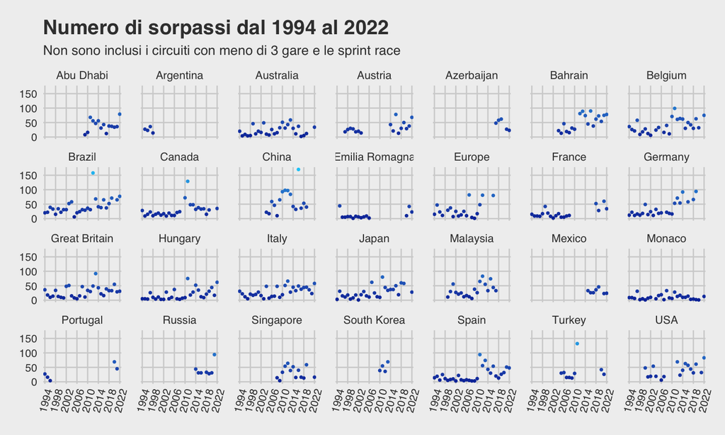

## È aumentato il numero di sorpassi con l’aggiunta del DRS?

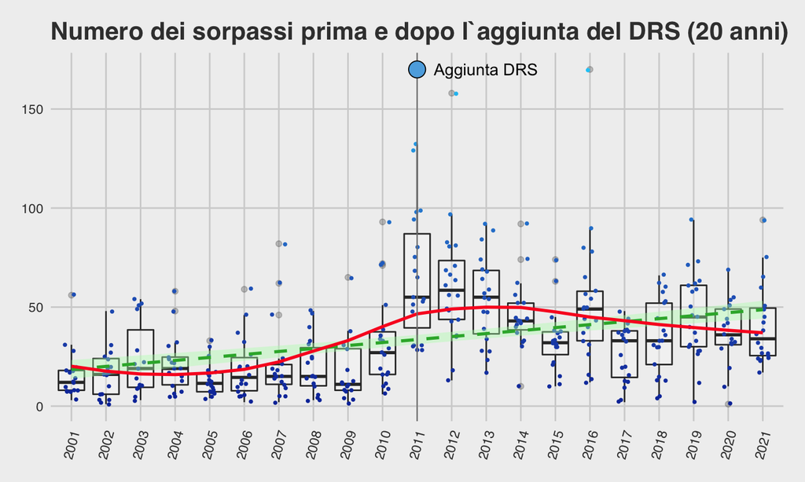

## Analisi:

Media dei sorpassi i 10 anni prima dell’aggiunta del DRS:

```
## [1] 20.4
```

Media dei sorpassi i 10 anni dopo dell’aggiunta del DRS:

```
## [1] 45
```

## È aumentato il numero di sorpassi con l’aggiunta del DRS?

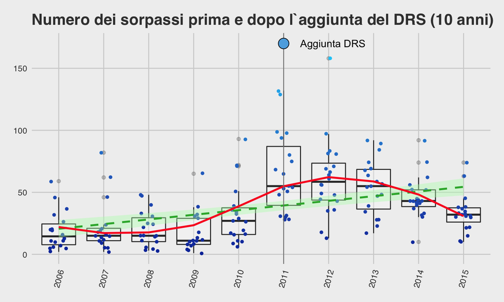

## Analisi:

Media dei sorpassi i 5 anni prima dell’aggiunta del DRS:

```
## [1] 23.9
```

Media dei sorpassi i 5 anni dopo dell’aggiunta del DRS:

```
## [1] 52.4
```

## Qual’è il circuito dov’è più facile sorpassare?

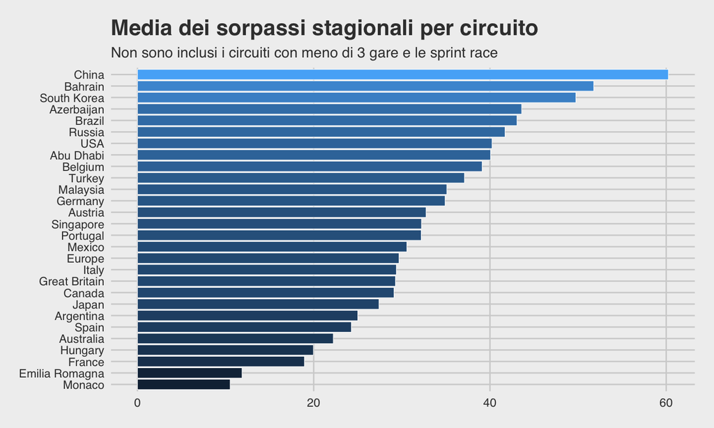

## Analizzando i circuiti con meno sorpassi:

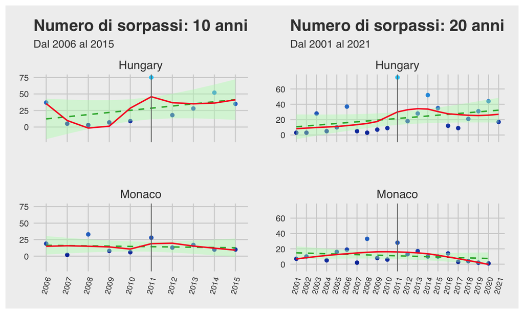

## Analisi:

Media e aumento dei sorpassi nel GP di Monaco:

```
## [1] "10 anni:  14.6 => Aumento del 14.7 %"
```

```
## [1] "20 anni:  10.9 => Diminuzione del -13.4 %"
```

Media e aumento dei sorpassi nel GP di Ungheria:

```
## [1] "10 anni:  26.9 => Aumento del 241 %"
```

```
## [1] "20 anni:  21.5 => Aumento del 182.6 %"
```

## Analizzando i circuiti con più sorpassi:

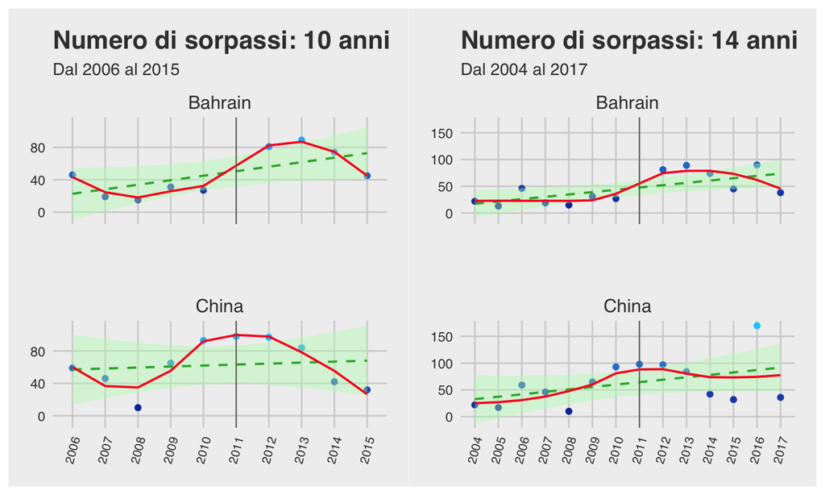

(In entrambi i circuiti il GP è iniziato solo nel 2004 quindi i 20 anni completi non sono visibili)

## Analisi:

Media e aumento dei sorpassi nel GP di Cina:

```
## [1] "10 anni:  62.6 => Aumento del 29.3 %"
```

```
## [1] "14 anni:  62.2 => Aumento del 79.2 %"
```

Media e aumento dei sorpassi nel GP di Bahrain:

```
## [1] "10 anni:  47.4 => Aumento del 161.8 %"
```

```
## [1] "14 anni:  45.4 => Aumento del 181.2 %"
```

## Oggi ci sono più sorpassi di una volta?

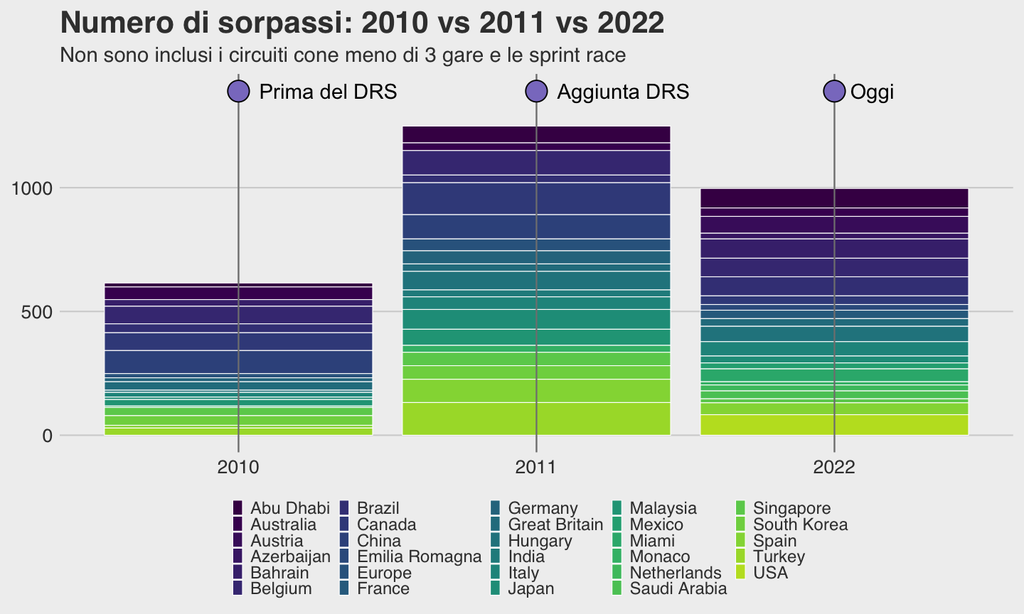

## Qual’è la stagione con più sorpassi?

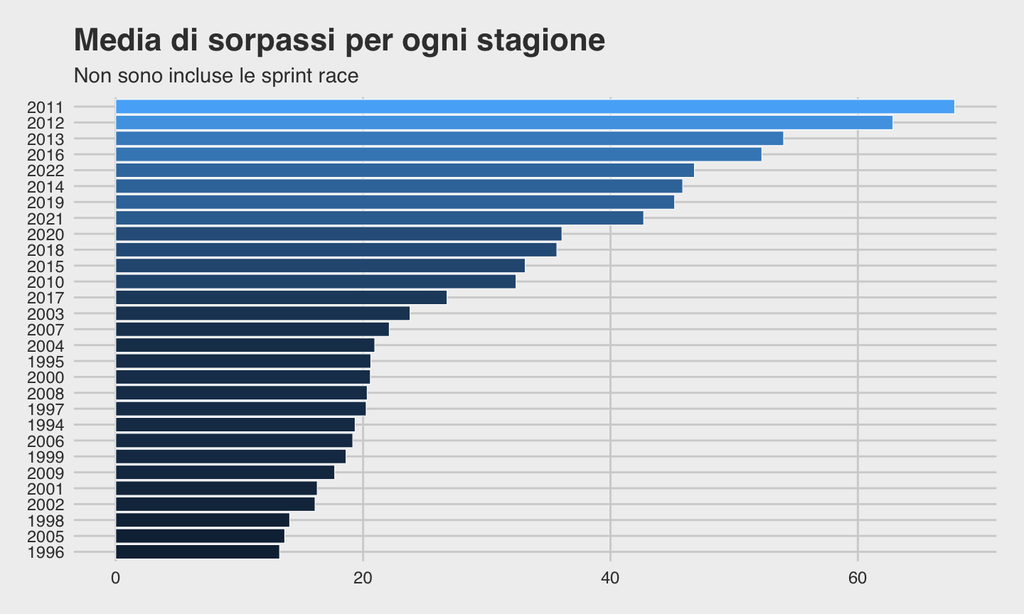

## Analisi:

Media dei sorpassi stagionali:

```
## [1] "2011 = 67.83"
```

```
## [1] "2012 = 62.84"
```

```
## [1] "2013 = 54"
```

## Qual’è il pilota che ha fatto più sorpassi?

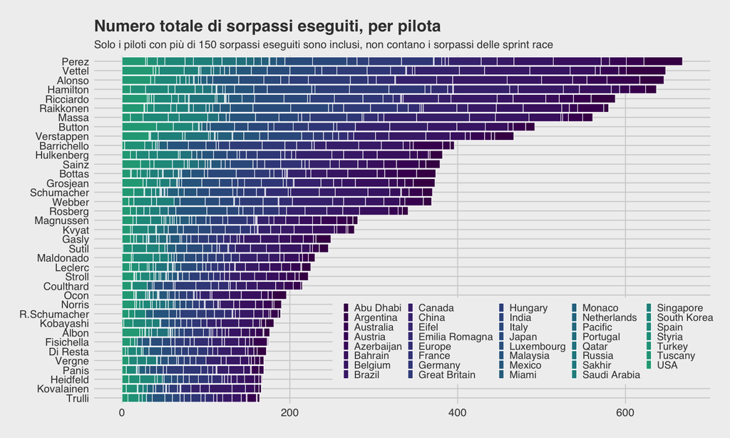

## Qual’è il pilota che ha subito più sorpassi?

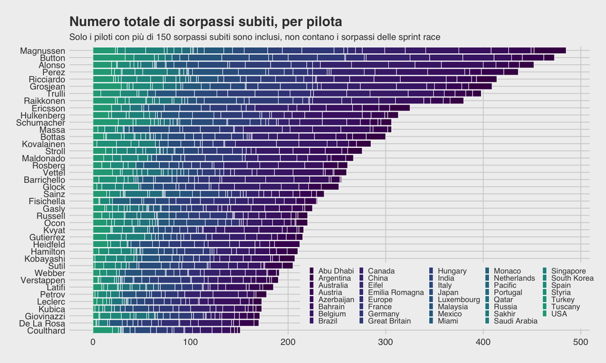

## Qual’è il pilota più forte a difendersi?

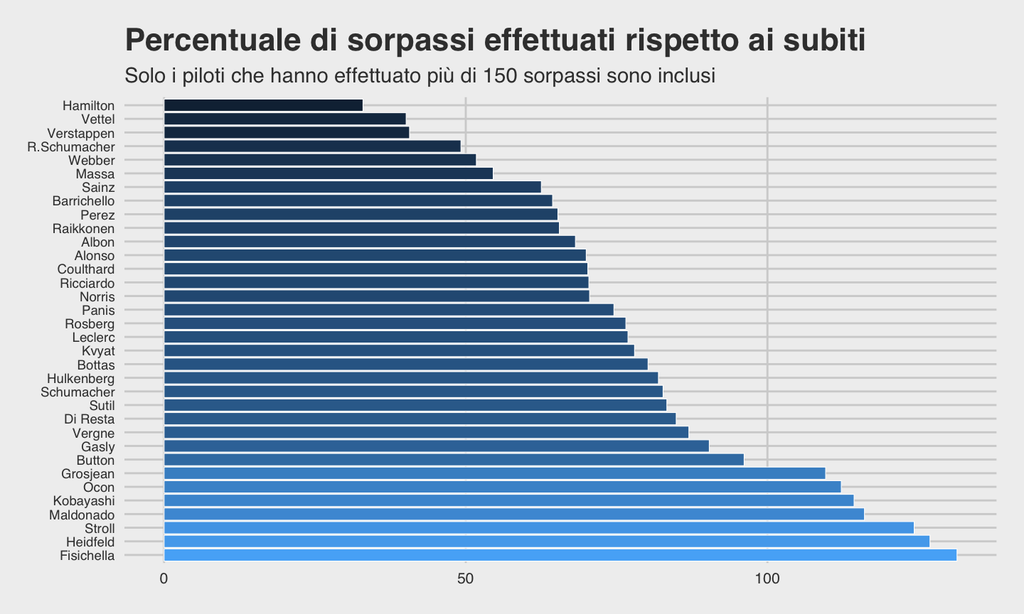

## Sorpassi nel GP d’Ungheria 2021 vs 2022

[figure not shown]

## Dove sono stati eseguiti questi sorpassi?

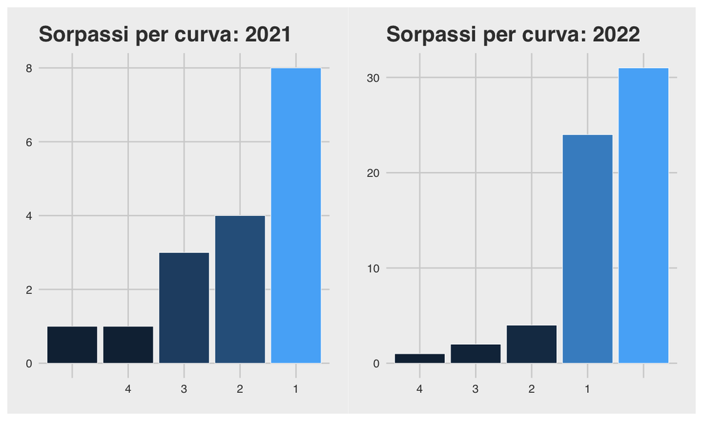

(Non tutti i sorpassi sono indicizzati ad una curva perchè non sono stati mostrati nella diretta)

## Analisi:

Togliendo i sorpassi “sconosciuti”, le curve in cui sono stati eseguiti più sorpassi sono: 1,2,3,4.

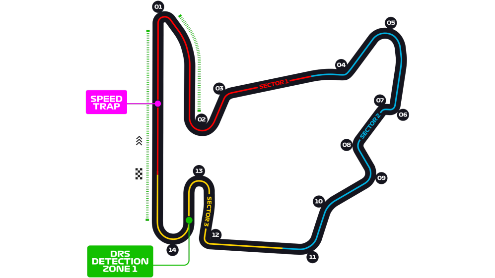

## Conclusioni

- Il DRS in F1 ha aumentato i sorpassi, ma bisogna considerare anche i progressi tecnologici e i nuovi regolamenti;
- Le condizioni intrinseche del circuito influiscono fortemente sui sorpassi (tipo Monaco);
- Il DRS è sicuramente una delle invenzioni che ha portato più innovazione negli ultimi anni, ma il 2022 è stato il primo passo per il prossimo cambiamanto;
- Ma la domanda rimane, la spettacolarità dell’F1 è stata compromessa dall’avvento del DRS?